# Examen 2 de Modelos lineales

Maria Jose Corea

2022-12-01

## Ejercicio 2.8 El registro de varvas glaciales representando en la Figura 2.6 exhibe cierta no estacionaridad que pude mejorarse transformandolo a logaritmos y algunos datos adicionales a la no estacionalidad que se puede corregir diferenciado los logaritmos.

1. Argumente que la serie de varvas glaciales, digamos $x_t$ exhibe heteroeslasticidad por calcular la varianza muestral sobre la primera mitad de los datos. Argumente que la transformación $y_t=log x_t$ estabiliza la varianza sobre la serie. Trace los histogramas de $x_t$ e $y_t$ para ver si la aproximación a la normalidad se mejora transformando los datos.

Solución

1. La varianza en la segunda mitad de la serie de varvas es obviamente mayor que la de la primera mitad. Dividiendo los datos a la mitad dan $γ_x(0)$ = 133, 594 para la primera y segunda parte respectivamente y la varianza es aproximadamente 4,5 veces más grande en la segunda mitad. La serie transformada $y_t$ = ln xt tiene $γ_y(0)$ = .27, .45 para las dos mitades, respectivamente, y la varianza de la segunda mitad es solo alrededor de 1,7 veces mayor. Los histogramas, calculados para las dos series de la figura 2.1, indican que la transformación mejora la aproximación normal.

```r
library(astsa)
data(varve)
data(oil)
634/2
```

```
## [1] 317
```

```r
317
```

```
## [1] 317
```

```r
varv1 = varve[1:317]
varv2 = varve[318:634]
var(varv1) # = 133.4574
```

```
## [1] 133.4574
```

```r
var(varv2) # = 594.4904
```

```
## [1] 594.4904
```

```r
var(log(varv1)) # = 0.2707217
```

```
## [1] 0.2707217
```

```r
var(log(varv2)) # = 0.451371
```

```
## [1] 0.451371
```

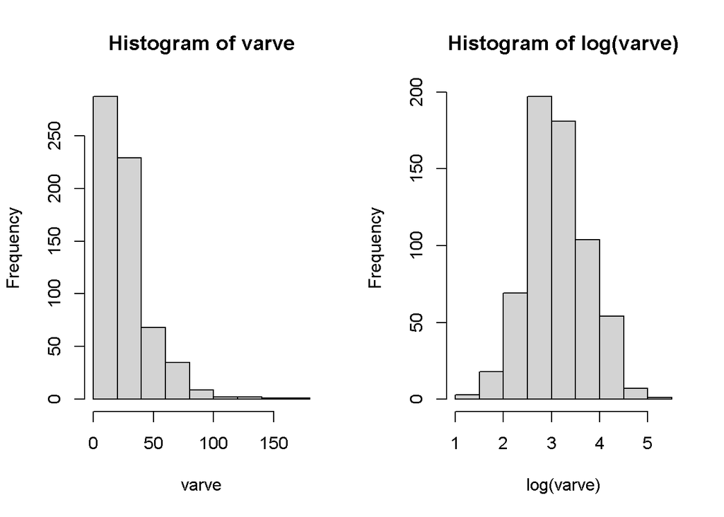

```r
par(mfrow=c(1,2))
hist(varve)
hist(log(varve))
```

Logró acomodar mejor los datos. Es mejor ajuste. (b) Trace la serie $y_t$ ¿Existen intervalos de tiempo del orden de 100 años donde se puede observar un comportamiento comparable al observado en el mundo de los registros de temperatura en la figura 1.2?

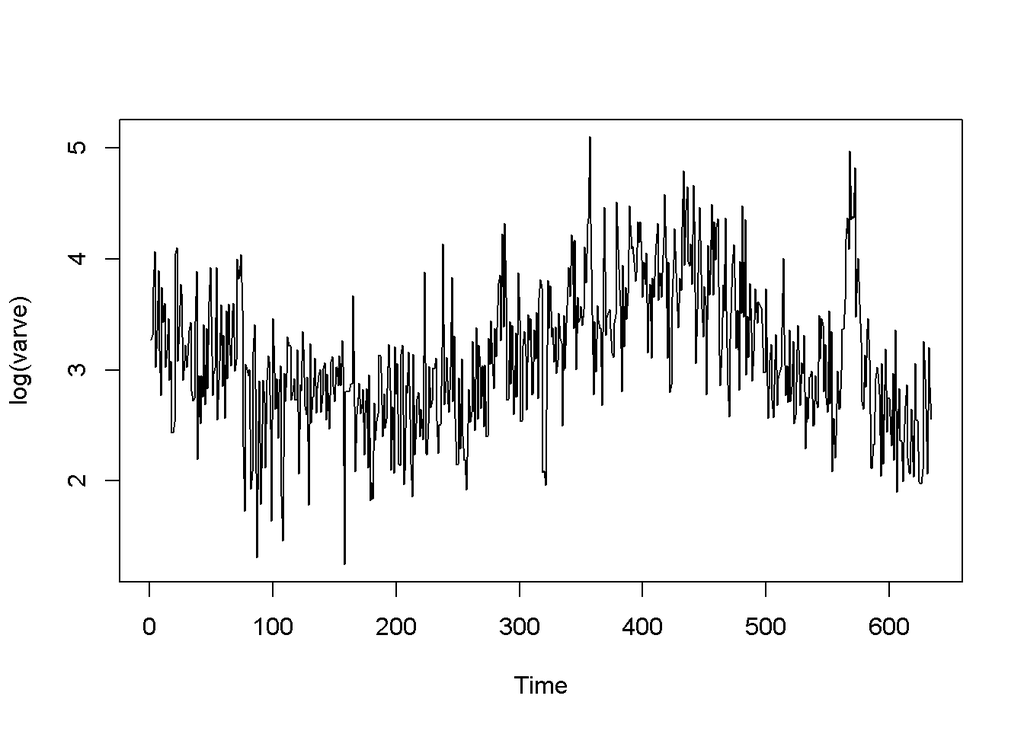

```r
plot(log(varve))
```

Estamos comparando dos bases que aparentan correlación. Se observa que no hay estacionalidad

Los datos entre 300 y 450 muestran una tendencia positiva que es similar a los datos de temperatura global. (Presumiblemente, esto se debe a una diferencia en la rotación de la Tierra).

3. Examine la muestra ACF de $y_t$ y comente. ElACF noa ayuda distinguir la correlaciones a laos ditiontos lags, y nos ayuda a distinguir un posible modelo MA, la dependencia anterior de los recios, correlacion correspecto a los otros lags, la dependencia de los residuos pasados (MA, ES LA CORRELACION CON LOS RESIDUOS PASADOS) si uno quiere ver el modelo AR(Es la correlacion a los mismo observación, no a los residuos del pasado) PACF es el que hace (modela) AR

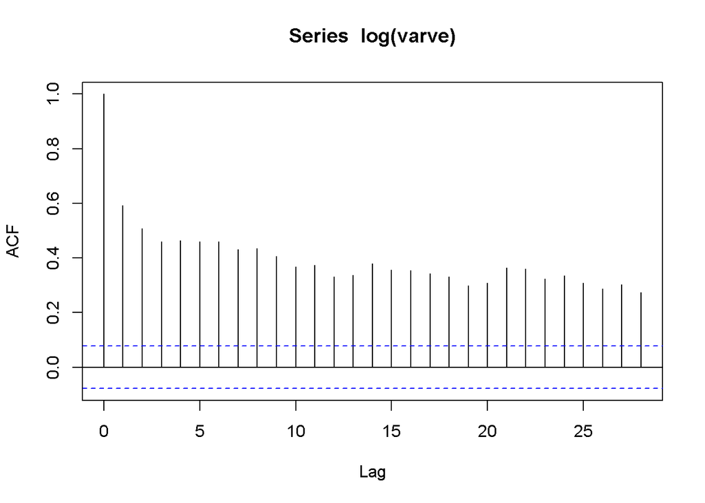

```r
acf(log(varve))
```

Aún no podemos diferenciar un ruido blanco puesto que la serie de tiempo no cae exponencialmente a la banda. Se observa una alta correlación en el primer lag, y esto se debe a que se sabe que siempre va a haber alta correlación asimismo. Se observa alta correlación entre los meses. El ACF de yt es positivo para una gran cantidad de rezagos y disminuye de forma lineal.

4. Calcule la diferencia $u_t=y_t-y_{t-1}$ examine su gráfica de los datos de varva registrados produce una serie razonablemente estacionario.¿Puedes pensar en una interpretación práctica para Utah? Pista: Para |p| cerca de cero, log(1+p)$\approx$p: sea

$$P=\dfrac{y_t-y_{t-1}}{y_{t-1}}$$

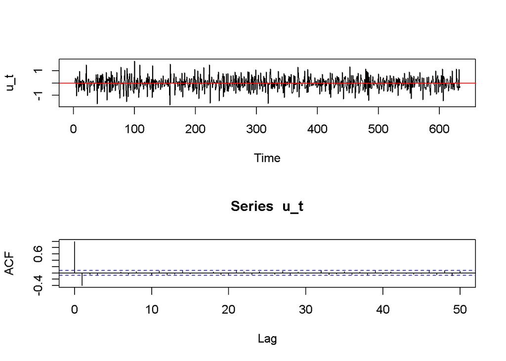

```r
u_t <- diff(log(varve))
par(mfrow=c(2,1))
plot(u_t)
abline(h = 0, col="red")
acf(u_t, lag.max = 50)
```

```r
rhos <- acf(u_t)
rhos$acf[2] # rho(1)
```

```
## [1] -0.3974306
```

```r
#varianza*n-1/n

round(var(u_t) *( (length(varve)-1)/ length(varve)), 4)#gamma(0)=varianza
```

```
## [1] 0.3317
```

```r
u = as.numeric(u_t)
round(sum((u-mean(u))^2)/length(u), 4)#gamma(0)
```

```
## [1] 0.3317
```

[figure not shown]

La argumentación de estacionario viene de que la media es masomenos constante a lo largo de la serie (cero) y que la varianza también es constante La aplicación práctica es que como ver rendimiento logaritmicos o tasa de crecimiento de un punto a otro por lo de que Se observan volatilidades

2.10. a) Trace los datos en el mismo gráfico. ¿Cuál de las series simuladas mostradas en Sección 1.2 ¿A qué se parecen más estas series? ¿Crees que las series son estacionarias? (Explica tu respuesta)?

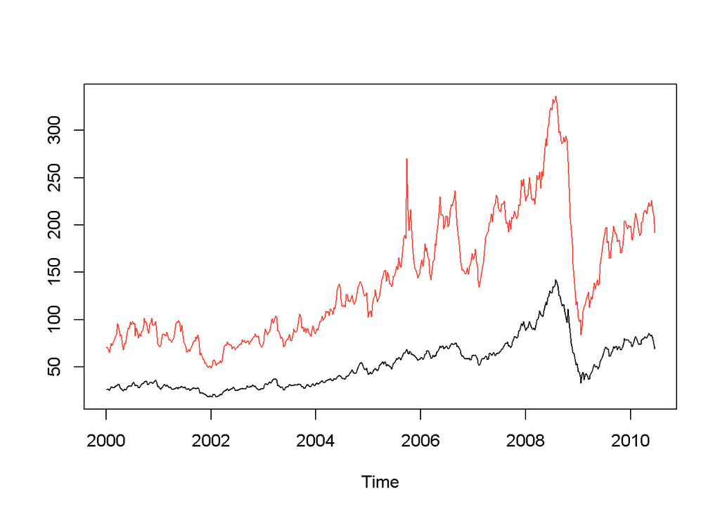

```r
data(gas)
ts.plot(oil, gas, col=1:2)
```

Se asemejan las series de tiempos, No parecen estacionarias por los picos.

b)En economía, a menudo es el cambio porcentual en el precio (denominado tasa de crecimiento o retorno), en lugar del cambio de precio absoluto, eso es importante. Argumentar que un la transformación de la forma yt = ∇ log xt podría aplicarse a los datos, donde xt es la serie de precios del petróleo o del gas. c) Transforme los datos como se describe en la parte (b), trace los datos en el mismo gráfico, observe en los ACF de muestra de los datos transformados y comente.

Respuesta de b y c

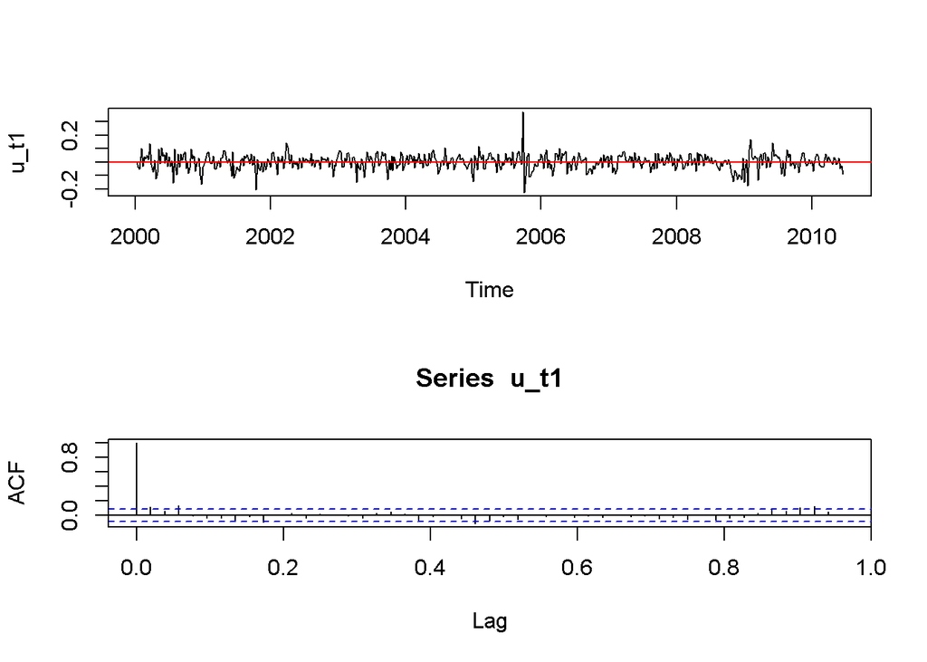

```r
u_t1 <- diff(log(gas))
par(mfrow=c(2,1))
plot(u_t1)
abline(h = 0, col="red")
acf(u_t1, lag.max = 50)
```

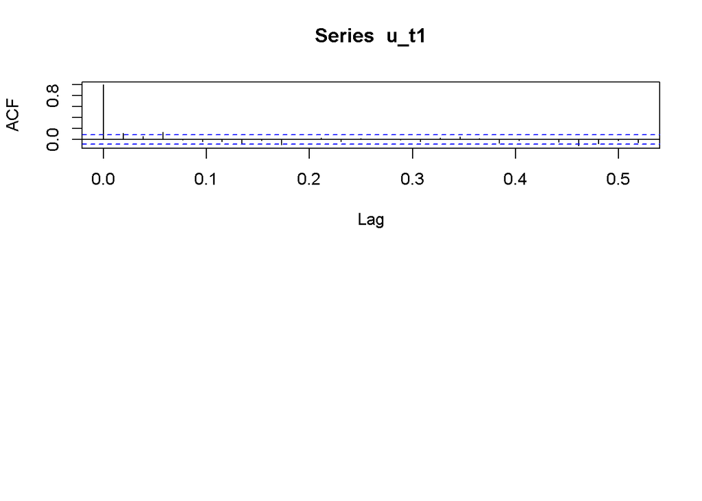

```r
rhos <- acf(u_t1)
```

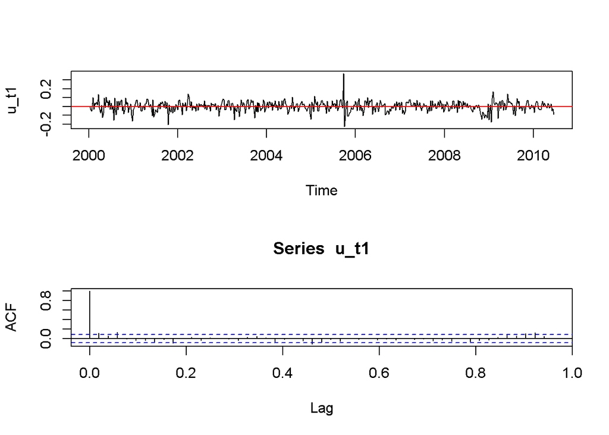

```r
u_t2 <- diff(log(oil))
par(mfrow=c(2,1))
plot(u_t1)
abline(h = 0, col="red")
acf(u_t1, lag.max = 50)
```

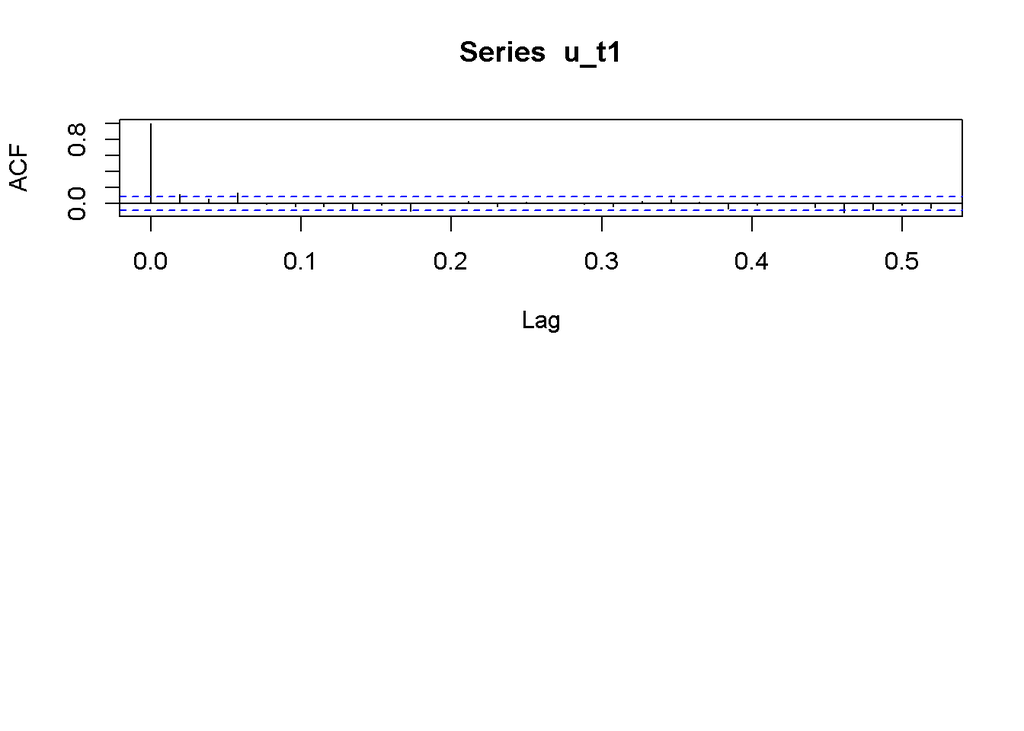

```r
rhos <- acf(u_t1)
```

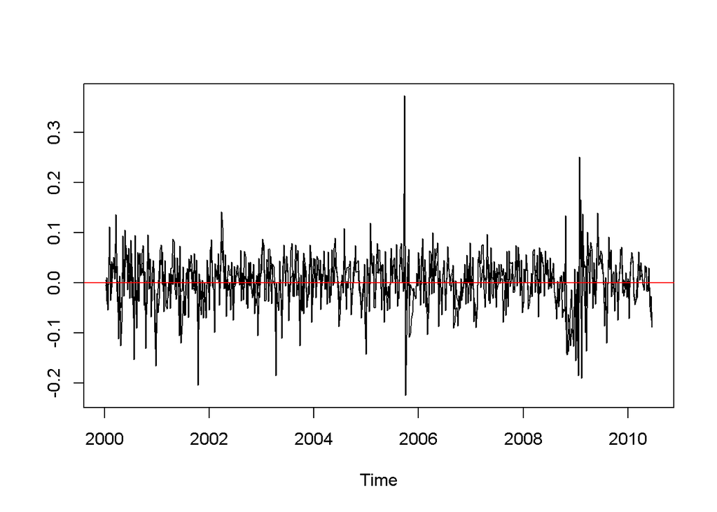

```r
ts.plot(u_t1,u_t2)
abline(h = 0, col="red")
```

Se observa una media concentrada en 0, pero picos de volatilidad, lo cual significa que no hay estacionalidad.La serie transformada parece estacionaria y hay muy poco la autocorrelación que queda después de la transformación, por lo que una caminata aleatoria parece plausible para cada serie.

Eso se puede verificar

```r
data(gas)
data(oil)
545/2
```

```
## [1] 272.5
```

```r
317
```

```
## [1] 317
```

```r
gas1 = gas[1:272]
gas2 = gas[273:545]
var(gas1)
```

```
## [1] 408.5202
```

```r
var(gas2)
```

```
## [1] 2458.069
```

```r
var(log(gas1))
```

```
## [1] 0.0519771
```

```r
var(log(gas2))
```

```
## [1] 0.0648478
```

```r
oil1 = oil[1:272]
oil2 = oil[273:545]
var(oil1)
```

```
## [1] 52.20158
```

```r
var(oil2)
```

```
## [1] 441.3429
```

```r
var(log(oil1))
```

```
## [1] 0.04777901
```

```r
var(log(oil2))
```

```
## [1] 0.07258206
```

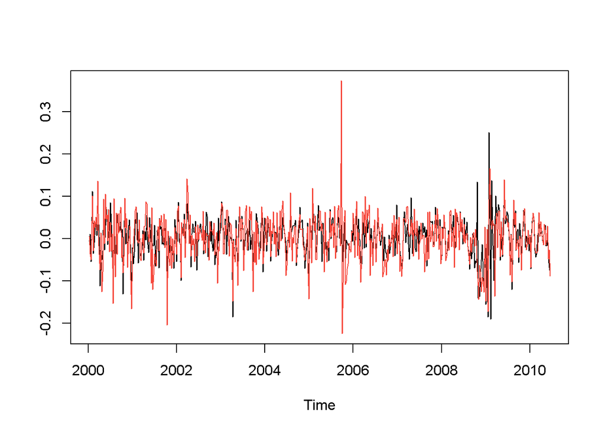

```r
poil = diff(log(oil))
pgas = diff(log(gas))
ts.plot(poil, pgas, col=1:2)
```

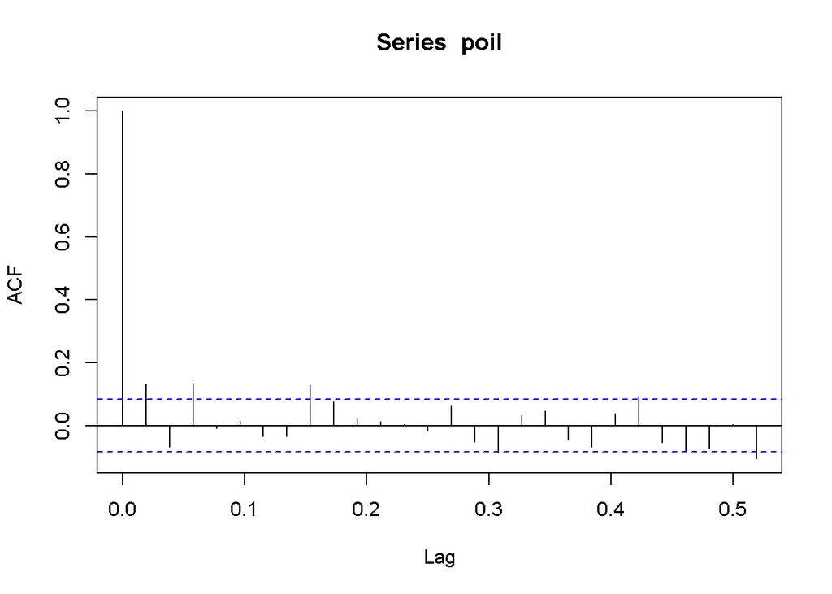

```r
acf(poil)
```

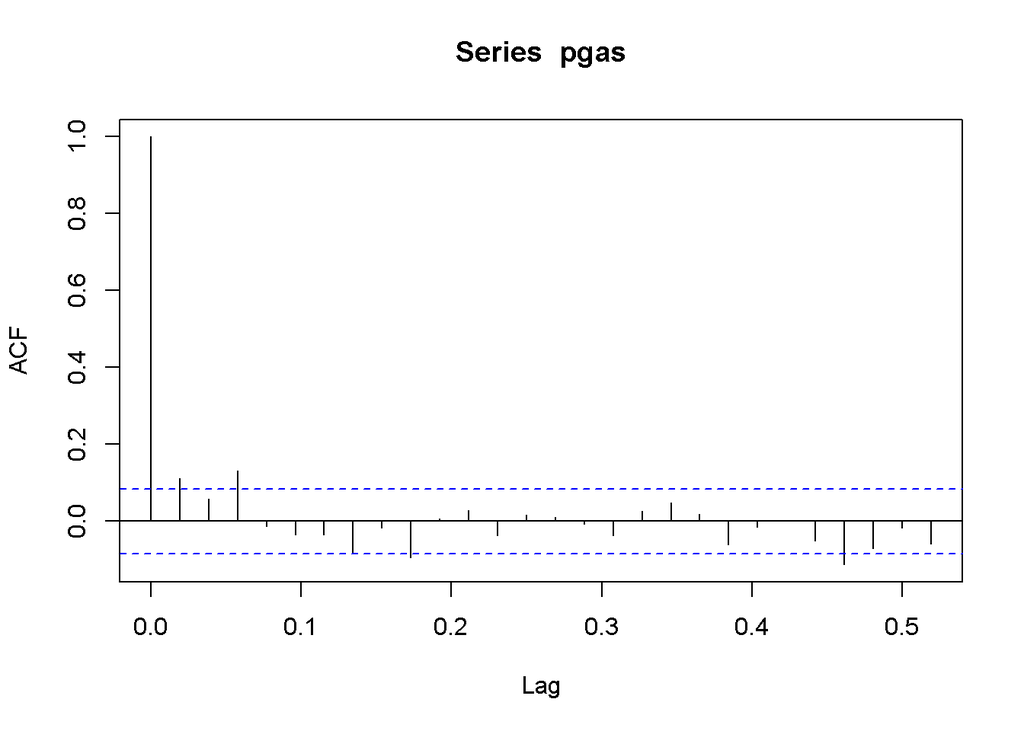

```r
acf(pgas)
```

Parece que de fijo si hay estacionalidad en gas y con oil está la variabilidad un poco distanciadas, pero parece que no son similares entre ambas mitades pero no iguales.

d)Trace el CCF de los datos transformados y comente El pequeño, pero significativo los valores cuando el gas lleva al petróleo pueden considerarse como retroalimentación. Existen algunos valores muy extremos [se indica a los estudiantes que observen los valores atípicos en la parte (e)]. Las dos series parecen ser moviéndose al mismo tiempo [esto se enfatiza en las partes (d) y (e)].

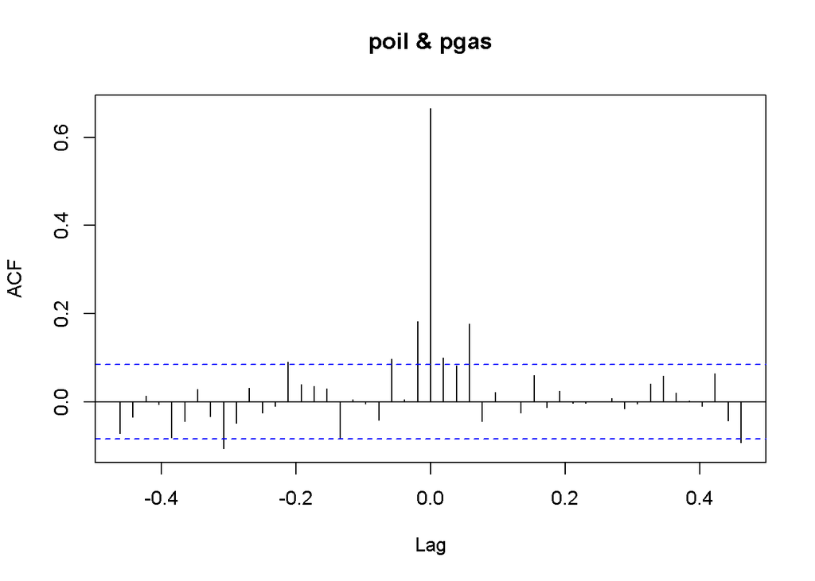

```r
ccf(poil, pgas)
```

```r
# corr[poil(t+Lag), pgas(t)]
```

En este ejemplo nos está interesanto el gas, por eso poil está en la primera entradas, son todos los lags respeto a gas

Existe una fuerte correlación cruzada en el desfase cero [.66] y el poil una semana más adelante [.18]. También hay retroalimentación para pgas tres semanas antes [.17]. Como se indica en la sugerencia, ccf(poil, pgas) tiene aceite líder para valores negativos de Lag; es decir, R calcula corr[poil(t+Lag), pgas(t)] para Lag = 0, ±1, ±2, Tambien se nota los periodos de mayor volatilidad, pero se ve que la media anda en cero, en general parece que puede no haber una estacionalidad, puesto que depende algo adicional

e)Mostrar diagramas de dispersión de la serie de tasas de crecimiento del petróleo y el gas durante un máximo de tres semanas del tiempo de entrega de los precios del petróleo; incluir un suavizador no paramétrico en cada gráfico y Comente los resultados (p. ej., ¿hay valores atípicos? ¿Las relaciones son lineales?).

```r
install.packages('astsa')
```

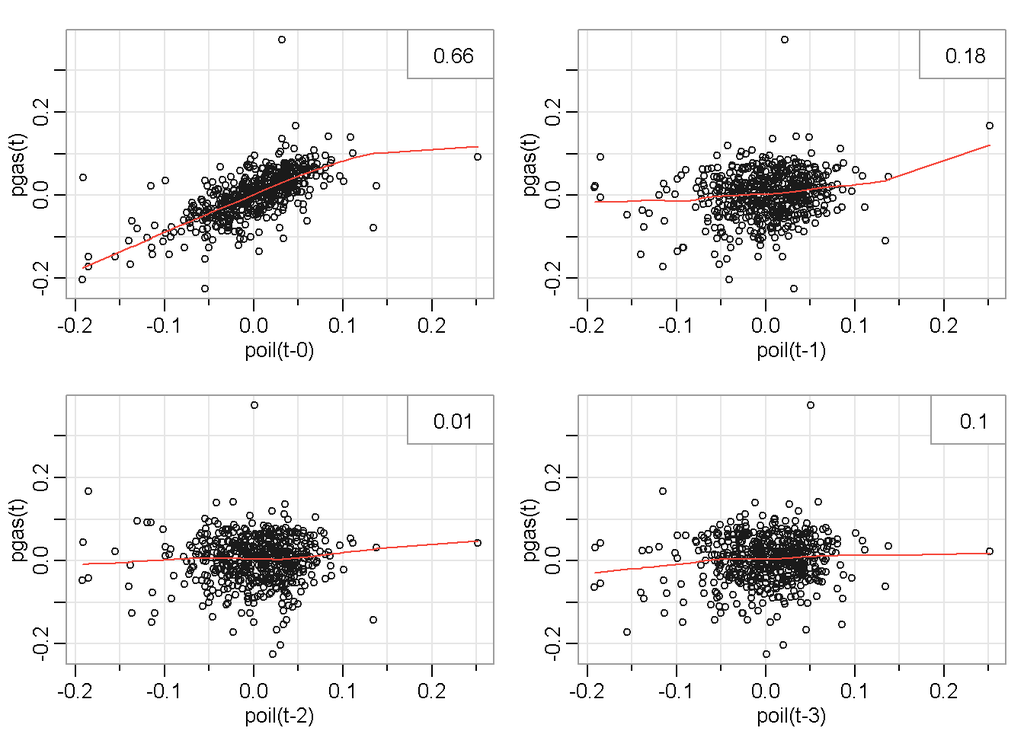

```r
  library('astsa')
 lag2.plot(poil, pgas, 3)
```

6. Ha habido una serie de estudios que cuestionan si los precios de la gasolina responden más rápido cuando los precios del petróleo están subiendo que cuando los precios del petróleo están cayendo (“asimetría”). Intentaremos explorar esta cuestión aquí con una regresión retardada simple; ignoraremos algunos problemas obvios, como valores atípicos y errores autocorrelacionados, por lo que este no será un análisis definitivo. Sean Gt y Ot el gas y el petróleo las tasas de crecimiento.
1. Ajuste la regresión (y comente los resultados) Gt = α1 + α2It + β1Ot + β2Ot−1 + peso, donde It = 1 si Ot ≥ 0 y 0 en caso contrario (It es el indicador de no crecimiento o crecimiento positivo del precio del petróleo). Insinuación:

```r
poil = diff(log(oil))
pgas = diff(log(gas))
indi = ifelse(poil < 0, 0, 1)
mess = ts.intersect(pgas, poil, poilL = lag(poil,-1), indi)
summary(fit <- lm(pgas~ poil + poilL + indi, data=mess))
```

```
##
## Call:
## lm(formula = pgas ~ poil + poilL + indi, data = mess)
##
## Residuals:
##      Min       1Q   Median       3Q      Max
## -0.18451 -0.02161 -0.00038  0.02176  0.34342
##
## Coefficients:
##              Estimate Std. Error t value Pr(>|t|)
## (Intercept) -0.006445   0.003464  -1.860  0.06338 .
## poil         0.683127   0.058369  11.704  < 2e-16 ***
## poilL        0.111927   0.038554   2.903  0.00385 **
## indi         0.012368   0.005516   2.242  0.02534 *
## ---
## Signif. codes:  0 '***' 0.001 '**' 0.01 '*' 0.05 '.' 0.1 ' ' 1
##
## Residual standard error: 0.04169 on 539 degrees of freedom
## Multiple R-squared:  0.4563, Adjusted R-squared:  0.4532
## F-statistic: 150.8 on 3 and 539 DF,  p-value: < 2.2e-16
```

2. ¿Cuál es el modelo ajustado cuando hay un crecimiento negativo en el precio del petróleo en el momento t? ¿Cuál es el modelo ajustado cuando no hay crecimiento o hay un crecimiento positivo en el precio del petróleo? ¿Estos resultados apoyan la hipótesis de la asimetría?

3. Analizar los residuos del ajuste y comentar.

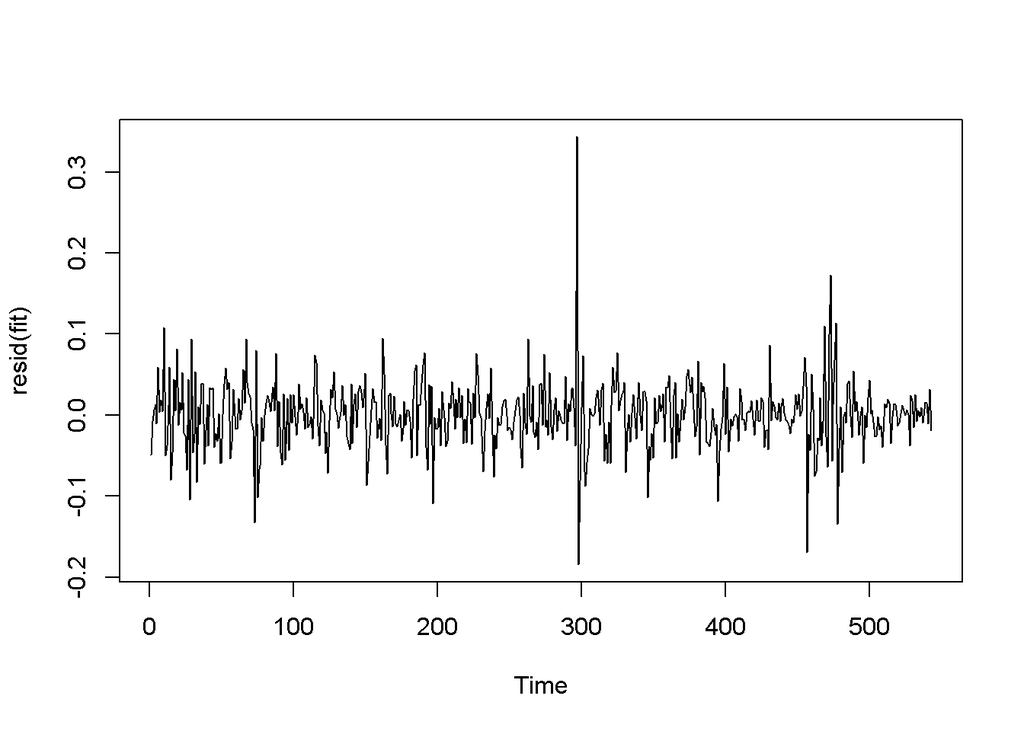

```r
plot.ts(resid(fit))
```

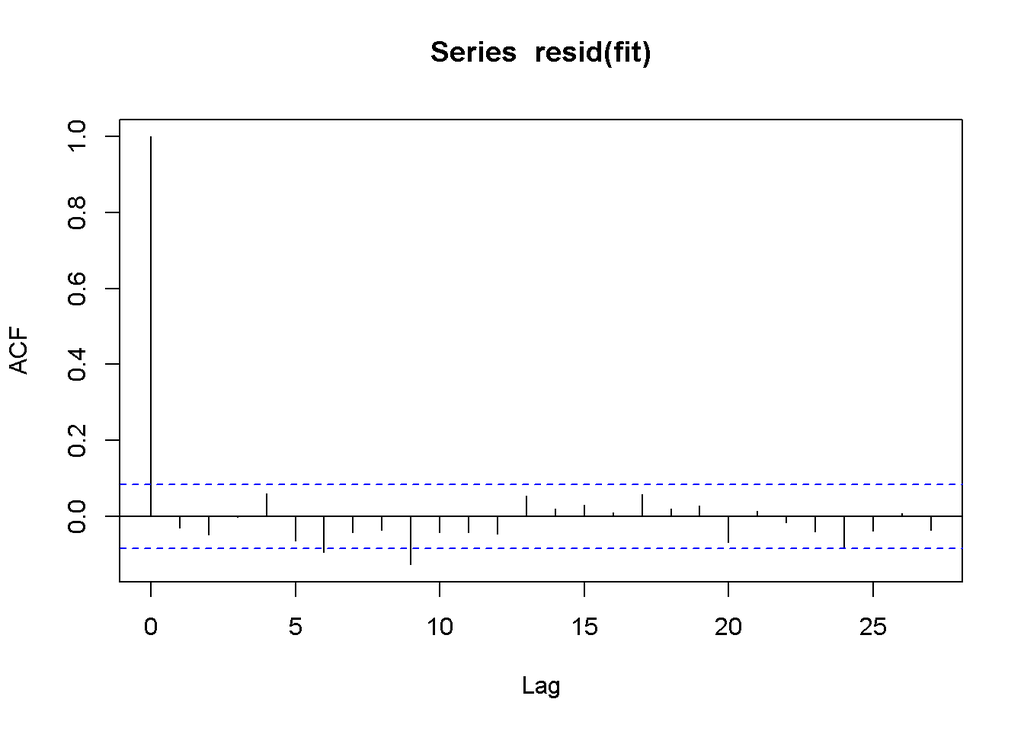

```r
 acf(resid(fit))
```

Se ajusta muchísimo mejor, excepto por los outliers.

3.22 Genere n = 50 observaciones a partir de un modelo Gaussiano AR(1) con φ = 0.99 y σw = 1. Usando una técnica de estimación de su elección, compare la distribución asintótica aproximada de su estimación (la que usaría para inferencia) con los resultados de un experimento de arranque (utilice B = 200).

A continuación se muestra el código R para este ejemplo usando Yule-Walker. La distribución asintótica es normal con media .99 y error estándar p(1 − .992)/50 ≈ .02. La distribución de arranque debe ser muy diferente a la distribución asintótica. (Si los estudiantes usan MLE, puede haber problemas porque φ está muy cerca del límite.Puede alertar a los alumnos sobre este hecho o dejar que lo averigüen por sí mismos).

```r
set.seed(666)

x = arima.sim(list(ar=.99), n=50)
fit = ar.yw(x, order=1)#.yw por .mle
m=fit$x.mean
phi = fit$ar # estimate of phi
nboot = 200 # number of bootstrap replicates
resids = fit$resid[-1] # the first resid is NA
x.star = x # x[1] stays the same throughout
phi.star = rep(NA, nboot)
for (i in 1:nboot) {
resid.star = sample(resids, replace=TRUE)
for (t in 1:49)
  x.star[t+1] = phi*x.star[t] + resid.star[t]
phi.star[i] = ar.yw(x.star, order=1)$ar #.yw por .mle
}
summary(phi.star);
```

```
##    Min. 1st Qu.  Median    Mean 3rd Qu.    Max.
##  0.3280  0.6872  0.7446  0.7295  0.7925  0.8975
```

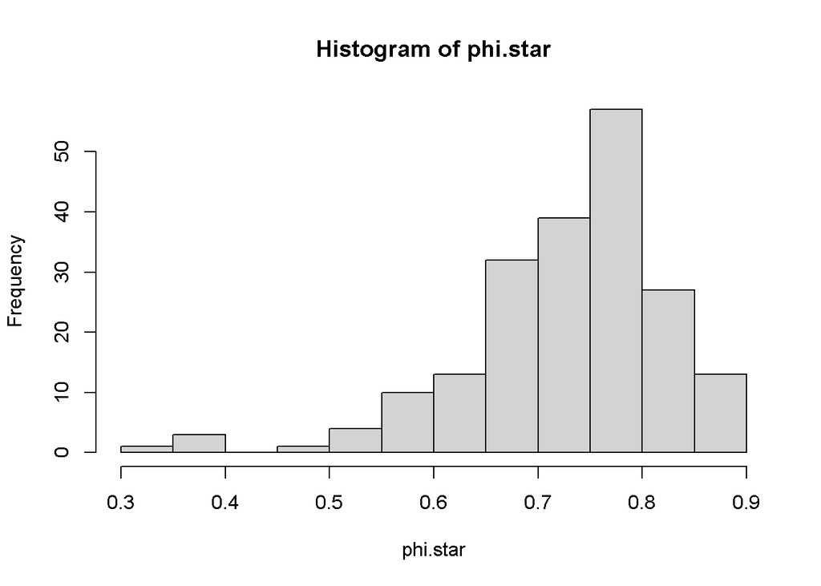

```r
hist(phi.star);
```

```r
stem(phi.star) # and so on ..
```

```
##
##   The decimal point is 1 digit(s) to the left of the |
##
##   3 | 3
##   3 | 679
##   4 |
##   4 | 7
##   5 | 1334
##   5 | 6778889999
##   6 | 1111333444
##   6 | 555566667777888888999999999
##   7 | 000000000111111112222222222223333334444444444
##   7 | 555555555555555666666677777777888888888888899999999
##   8 | 00000000000011111112223334444444
##   8 | 555556777779999
##   9 | 0
```

El objetivo es ver, que hay la approx lineal es mala idea por muestras pequeñas, con bootraping es una tecnica que le perimte utilizar técnica, modelar la distribución del error, sin tomar un supuesto paramétrico, se ven los supuestos de la normalidad, no es tan buena idea, entonces no es correcto usar la ml, ent mejor usar #.yw, se observa en el histograma.

3.34 Ajuste un modelo ARIMA(p, d, q) a la serie de dióxido de azufre, so2, realizando todos de los diagnósticos necesarios. Después de decidirse por un modelo apropiado, pronostique el datos en el futuro cuatro períodos de tiempo por delante (alrededor de un mes) y calcular el 95% intervalos de predicción para cada uno de los cuatro pronósticos. Comentario. (El dióxido de azufre es uno de los contaminantes monitoreados en el estudio de mortalidad descrito en el Ejemplo 2.2.)

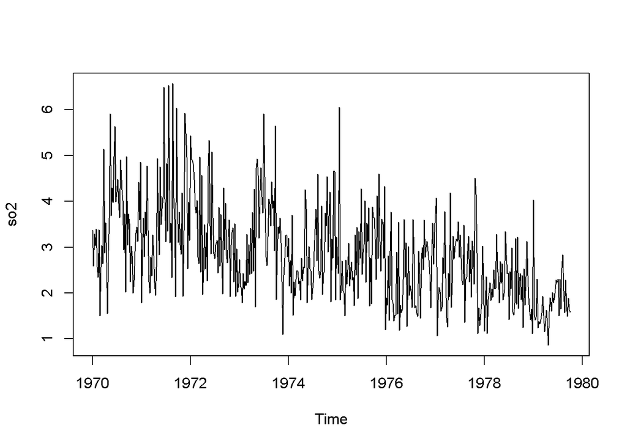

```r
data(so2)
plot(so2);
```

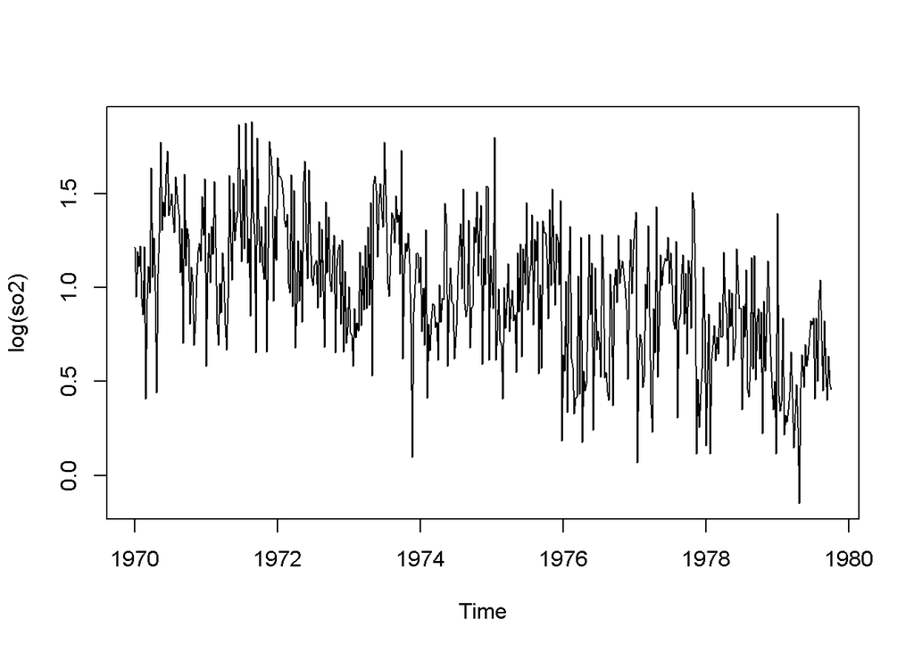

```r
plot(log(so2))
```

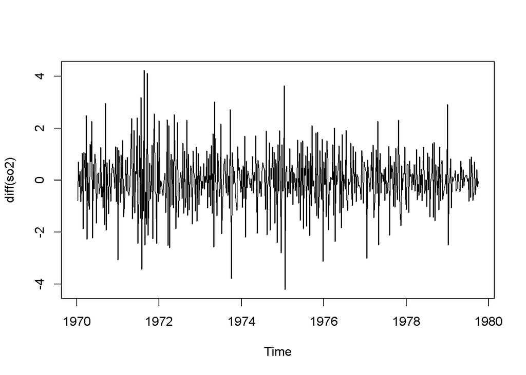

```r
plot(diff(so2))
```

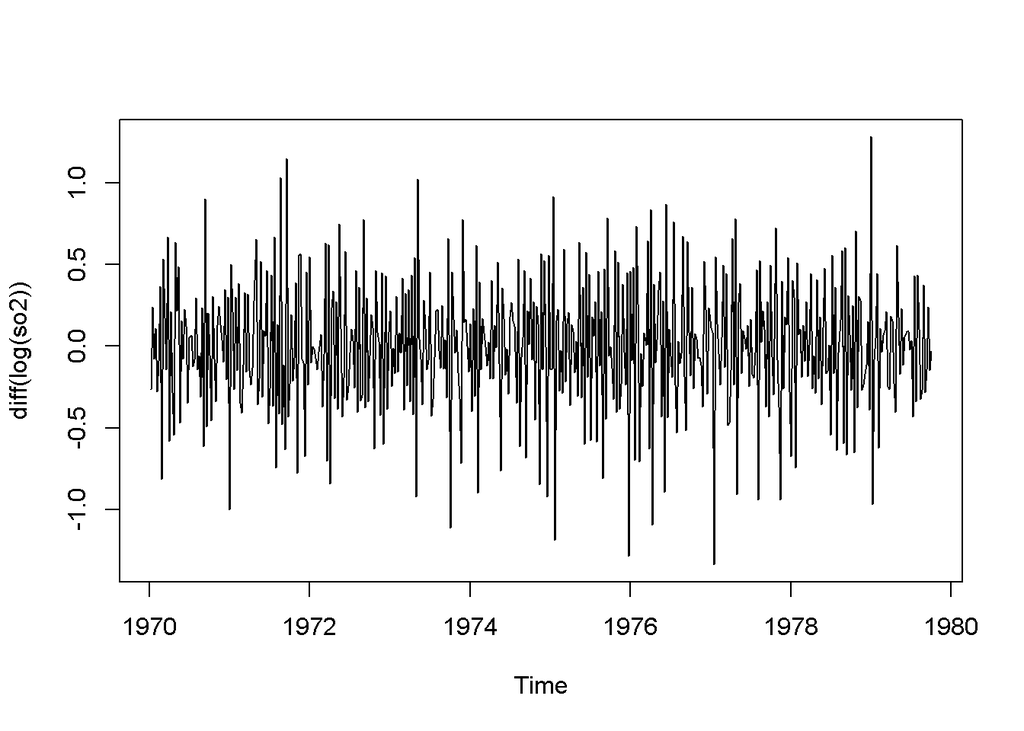

```r
plot(diff(log(so2)))
```

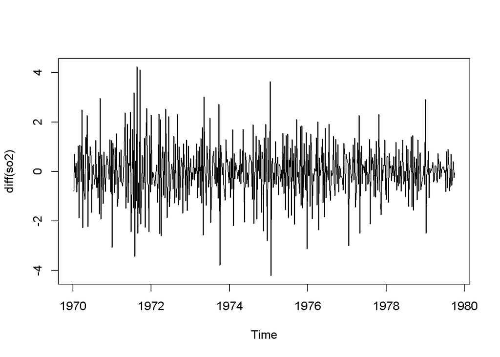

```r
plot(diff(so2))
```

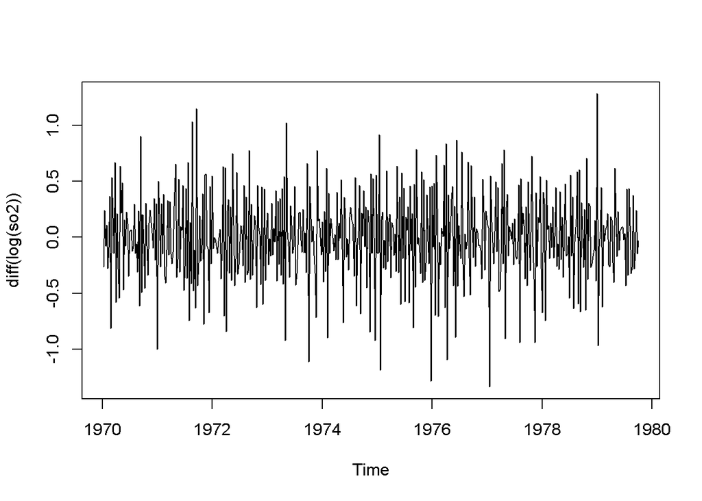

```r
plot(diff(log(so2)))
```

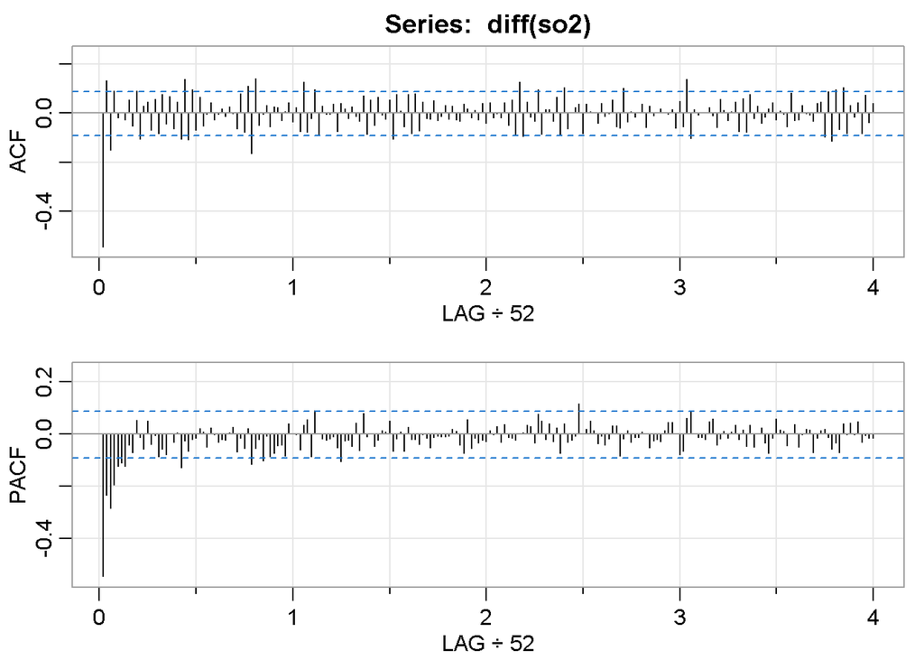

[output not shown]

```r
acf2(diff(so2))
```

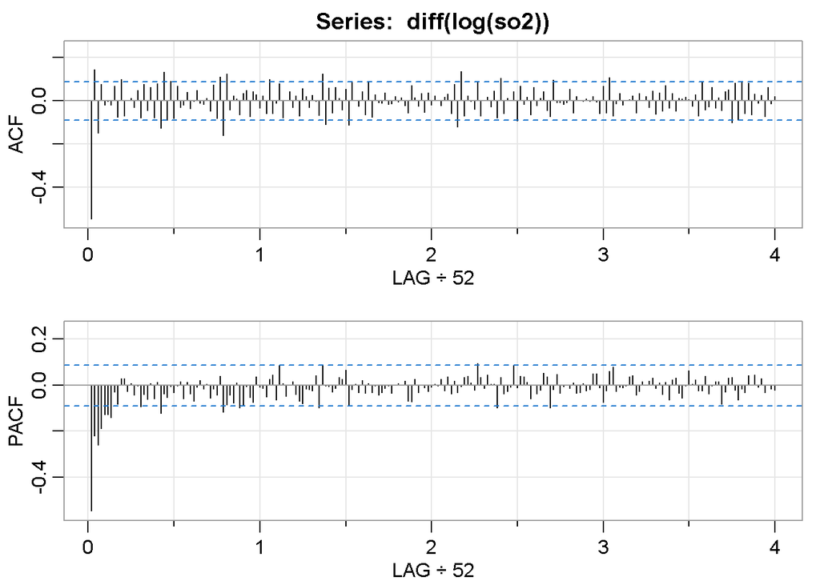

[output not shown]

```r
acf2(diff(log(so2)))
```

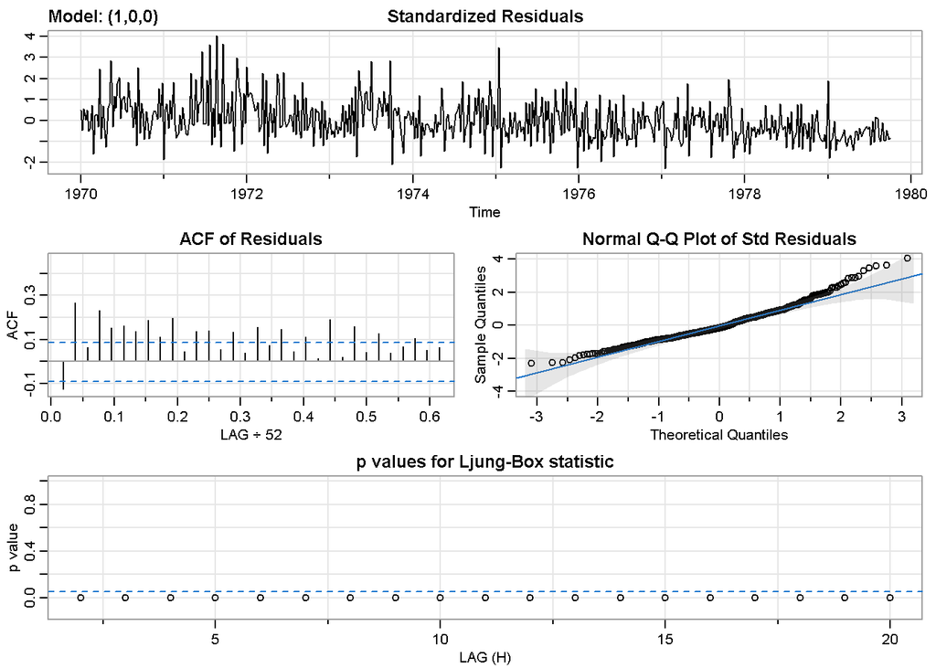

```
## $fit
##
## Call:
## arima(x = xdata, order = c(p, d, q), seasonal = list(order = c(P, D, Q), period = S),
##     xreg = xmean, include.mean = FALSE, transform.pars = trans, fixed = fixed,
##     optim.control = list(trace = trc, REPORT = 1, reltol = tol))
##
## Coefficients:
##          ar1   xmean
##       0.3737  2.8436
## s.e.  0.0412  0.0689
##
## sigma^2 estimated as 0.9477:  log likelihood = -707.25,  aic = 1420.5
##
## $degrees_of_freedom
## [1] 506
##
## $ttable
##       Estimate     SE t.value p.value
## ar1     0.3737 0.0412  9.0814       0
## xmean   2.8436 0.0689 41.2809       0
##
## $AIC
## [1] 2.796253
##
## $AICc
## [1] 2.7963
##
## $BIC
## [1] 2.821236
```

```r
#AR--->pacf
sarima(so2,1,0,0)
```

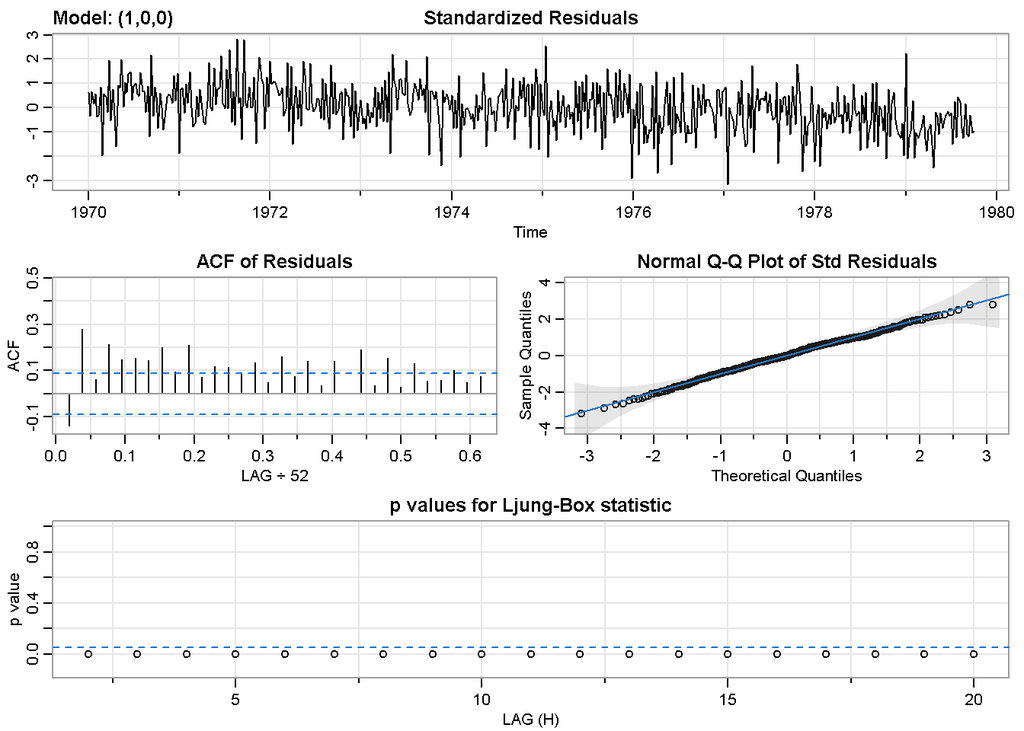

```
## $fit
##
## Call:
## arima(x = xdata, order = c(p, d, q), seasonal = list(order = c(P, D, Q), period = S),
##     xreg = xmean, include.mean = FALSE, transform.pars = trans, fixed = fixed,
##     optim.control = list(trace = trc, REPORT = 1, reltol = tol))
##
## Coefficients:
##          ar1   xmean
##       0.3983  0.9777
## s.e.  0.0407  0.0250
##
## sigma^2 estimated as 0.1155:  log likelihood = -172.56,  aic = 351.13
##
## $degrees_of_freedom
## [1] 506
##
## $ttable
##       Estimate     SE t.value p.value
## ar1     0.3983 0.0407  9.7800       0
## xmean   0.9777 0.0250 39.0741       0
##
## $AIC
## [1] 0.6911958
##
## $AICc
## [1] 0.6912426
##
## $BIC
## [1] 0.716179
```

```r
sarima(log(so2),1,0,0)
```

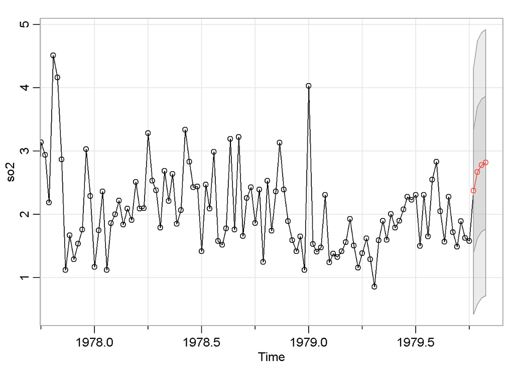

```
## $pred
## Time Series:
## Start = c(1979, 41)
## End = c(1979, 44)
## Frequency = 52
## [1] 2.371374 2.667119 2.777643 2.818947
##
## $se
## Time Series:
## Start = c(1979, 41)
## End = c(1979, 44)
## Frequency = 52
## [1] 0.9734922 1.0392505 1.0481061 1.0493369
```

```r
sarima.for(so2,4,1,0,0)
```